# Успеваемость первокурсников

Для 600 первокурсников известны показатели успеваемости по четырём предметам и результаты трёх психологических тестов. Как связаны эти два набора переменных?

```r
library(data.table)
DT <- fread("./mmreg.csv")
class(DT)  # inherits from data.table and data.frame
```

```
## [1] "data.table" "data.frame"
```

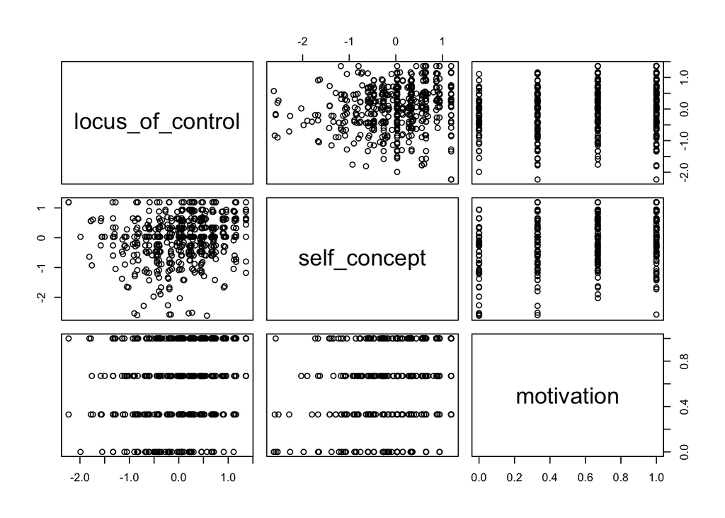

```r
psych <- DT[, 1:3, with=F]
plot(psych)
```

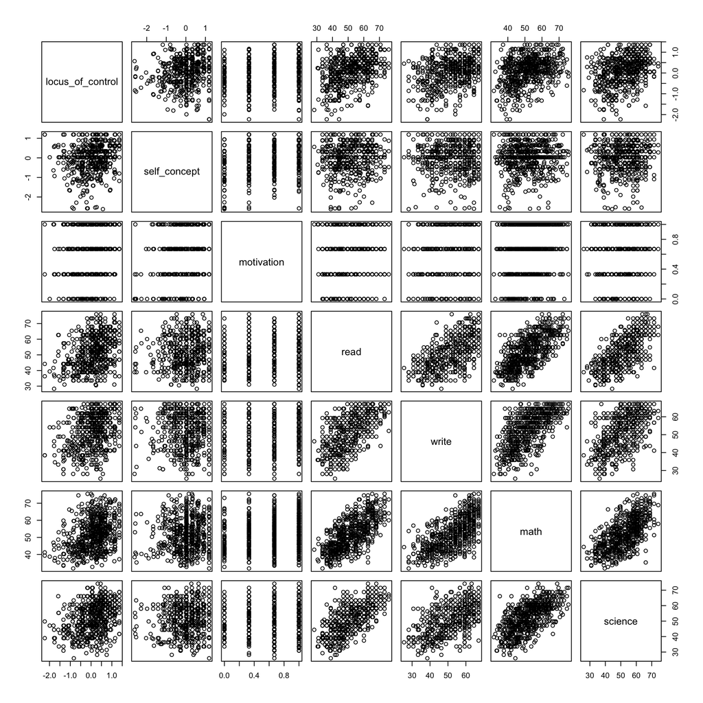

```r
plot(DT)
```

Визуализируйте попарные корреляции Пирсона с помощью функции `corrplot` из пакета `corrplot`, предаварительно посчитав их с помощью функции `rcorr` из пакета `Hmisc`. Для визуализации очень полезен параметр `method="pie"` функции `corrplot`.

```r
# type your code here
```

Визуализируйте попарные корреляции Спирмена с помощью функции `corrplot` из пакета `corrplot`, предаварительно посчитав их с помощью функции `rcorr` из пакета `Hmisc`.

```r
# type your code here
```

Визуализируйте попарные корреляции Кендалла с помощью функции `corrplot` из пакета `corrplot`, предаварительно посчитав их с помощью функции `cor` из стандартного пакета `stats`.

```r
# type your code here
```

Если вам не нужна полноценная матрица всевозможных корреляций, а нужна только попарная корреляция некоторых групп, гораздо удобнее воспользоваться станадртной функцией `cor` или `cor.test`. Последняя, кроме прочего, умеет, и проверять стат значимость всех трех видов корреляций (в том числе и Кендалла - то, что не умеет `rcorr` из пакета `Hmisc`). Примените функцию `cor.test` для любой из пар признаков, для которых `rcorr` выдает нулевое p-value. Совпадают ли значения p-value?

```r
# type your code here
```

## Перестановочные тесты

1. Принцип перестановок можно также использовать для проверки статистической значимости значения корреляции. Реализуйте перестановочный тест для корреляции Спирмена между `math` и `motivation`.

```r
# type your code here
```

2. Проверьте свой результат с помощью функции `spearmam_test` из пакета `coin`.

```r
# type your code here
```

## Частная корреляция

С помощью функции `pcor` из пакета `ppcor` получите значения частных корреляций Пирсона попарно между всеми переменными (при условии всех остальных) и сравните получившуюся матрицу с обычными попарными корреляциями, которые вы получили ранее.

```r
# type your code here
```

Кроме частной корреляции есть еще так называемая получастная (semi partial correlation). На практике такая корреляция используется редко, но концептуально это та же самая корреляция, только теперь вместо одного (и только одного) из признаков рассматривются отстаки от регрессии этого признака на какой-то другой признак (по которому мы берем условие). Подобные извращения также доступны в пакете `ppcor` с помощью функции `spcor`.

R Data Analysis Examples: Canonical Correlation Analysis. UCLA: Statistical Consulting Group. http://www.ats.ucla.edu/stat/r/dae/canonical.htm